# Gdelt Data Analysis

2017-07-25

# 1 Quad Class

**QuadClass** : (integer) The entire CAMEO event taxonomy is ultimately organized under four primary classifications: Verbal Cooperation, Material Cooperation, Verbal Conflict, and Material Conflict. This field specifies this primary classification for the event type, allowing analysis at the highest level of aggregation. The numeric codes in this field map to the Quad Classes as follows: 1=Verbal Cooperation, 2=Material Cooperation, 3=Verbal Conflict, 4=Material Conflict.

## 1.1 Quad Class Bar Graph

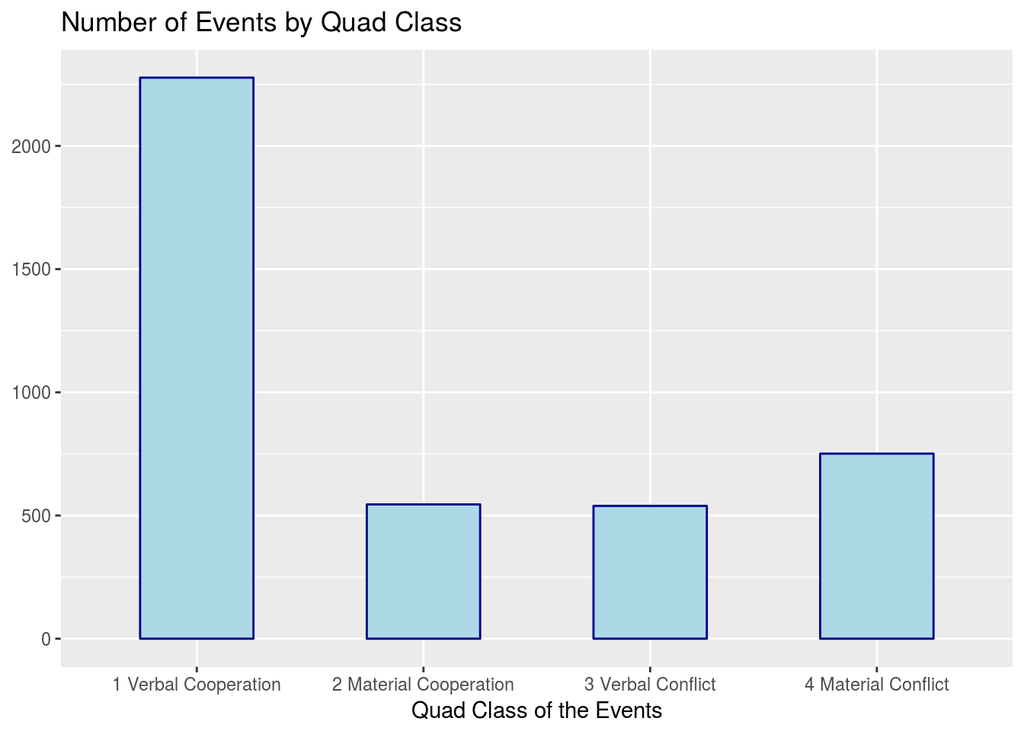

Back to top

## 1.2 Quad Class Article Tone

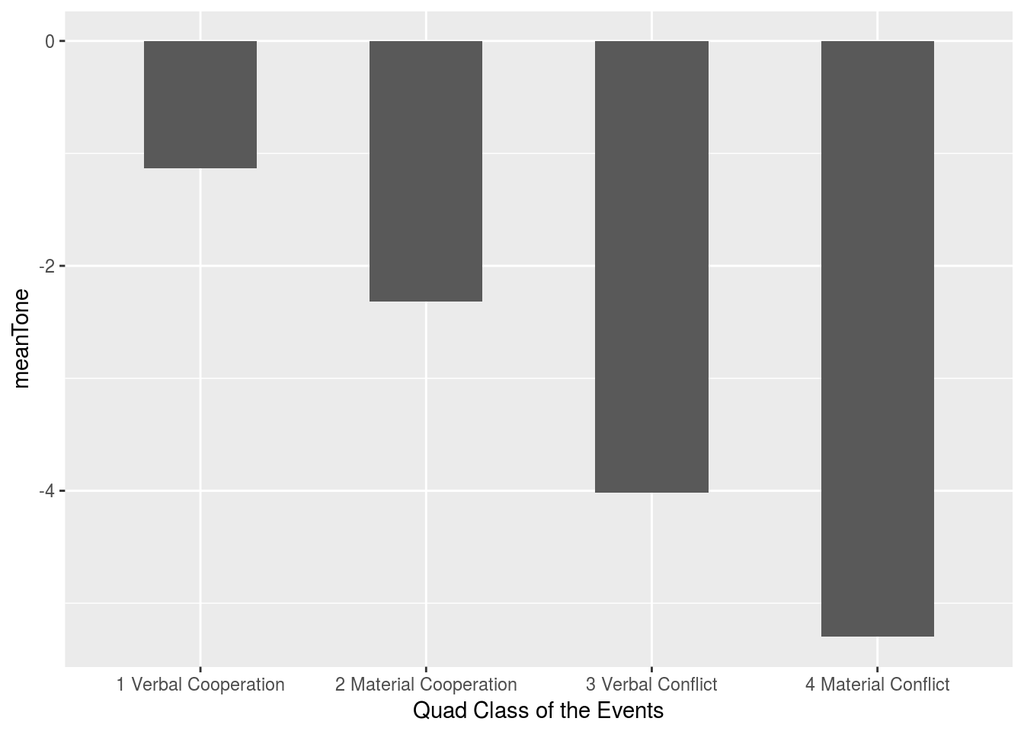

Back to top